# Analysis

John Clements and Jingjing Li

7/1/2021

# Introduction

```r
library(readr)
library(tidyverse)
library(cowplot)
library(caret)
library(rmarkdown)
```

# Reading in and Subsetting the Data

Before doing any analysis, we need to read in the daily bike-share data and subset for the day of interest.

```r
# Read in the daily data set.
bikeDay <- read_csv("./Bike-Sharing-Dataset/day.csv")
bikeDay <- filter(bikeDay, weekday == params$weekday)
```

Some of the variables, namely, `season`, `mnth`, `holiday`, `workingday`, and `weathersit` are categorical, but are stored numerically. Before proceeding with the analysis, we are converting them to `factor` data types.

```r
# Convert categorical variables stored numerically to factors.
bikeDay <- bikeDay %>%
  mutate(season = factor(ifelse(season == 1, "Spring",
                                ifelse(season == 2, "Summer",
                                       ifelse(season == 3, "Fall",
                                              "Winter"))),
                         levels=c("Spring", "Summer", "Fall", "Winter")),
         mnth = factor(mnth, levels=1:12),
         holiday = factor(holiday, levels=c(0, 1)),
         workingday = factor(workingday, levels=c(0, 1)),
         weathersit = ordered(weathersit, levels=c(1, 2, 3, 4))
         )
```

```r
# Set a random seed for reproducibility.
set.seed(10)

# Set the proportion of observations to use for training models.
trainProp <- 0.7

# Get indexes for the training and testing subsets of the daily data.
trainIndexes <- sample(1:nrow(bikeDay),
                          size=nrow(bikeDay)*trainProp)
testIndexes <- setdiff(1:nrow(bikeDay), trainIndexes)
# Use the indexes to separate the training and testing sets of the daily data.
bikeTrain <- bikeDay[trainIndexes, ]
bikeTest <- bikeDay[testIndexes, ]
```

With our data sets created, we can now begin exploring the data.

# Data Exploration

Let’s begin our exploration with a histogram of the number of bike rentals in a day for our given day of the week.

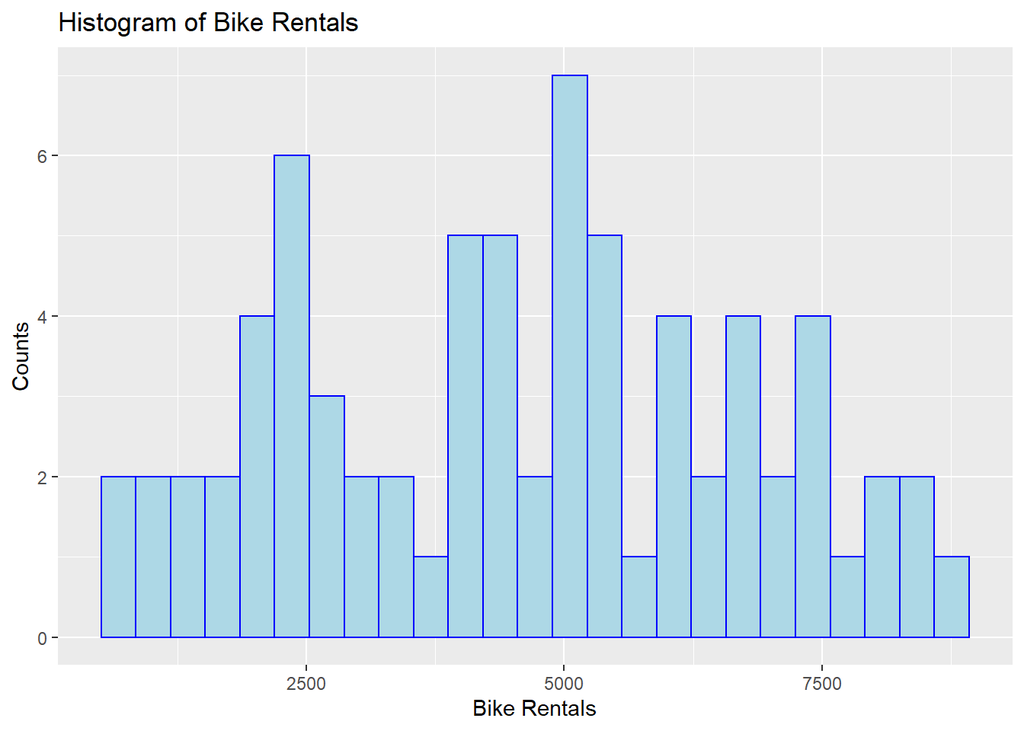

Next, let’s examine the numeric variables related to weather: temperature, humidity, and wind speed. Below are the means and standard deviations for each of these variables by season.

Table 1: Means and Standard Deviations for Daily Temp. (Celsius), Humidity, and Wind Speed (km/h)

| Season | Temp. Mean | Temp. Std. Dev. | Humidity Mean | Humidity Std. Dev. | Wind Speed Mean | Wind Speed Std. Dev. |
| --- | --- | --- | --- | --- | --- | --- |
| Spring | 11.55 | 3.88 | 52.37 | 16.46 | 16.74 | 7.41 |
| Summer | 22.31 | 5.62 | 64.21 | 16.89 | 12.45 | 4.18 |
| Fall | 28.83 | 3.35 | 64.39 | 12.58 | 13.36 | 4.33 |
| Winter | 15.72 | 4.58 | 59.96 | 13.60 | 12.99 | 6.55 |

The boxplots below conveys the distributions of these variables by season graphically.

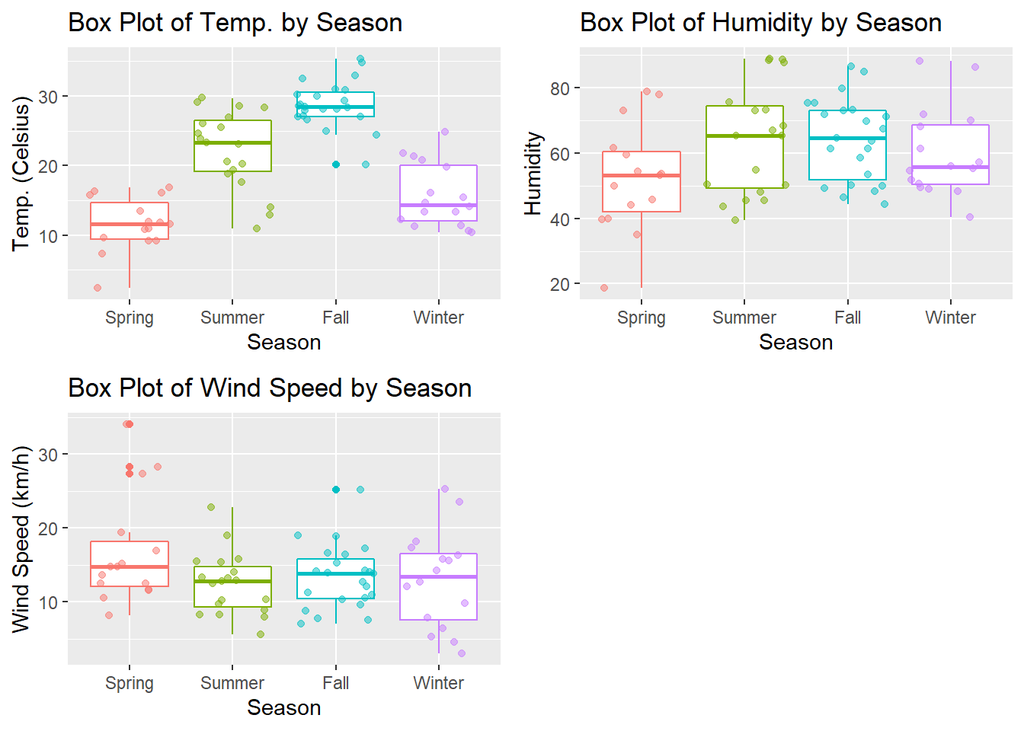

Now let’s examine the counts of weather situation by season.

Table 2: Weather Situation by Season

|  | Pleasant | Overcast | Unpleasant | Severe |
| --- | --- | --- | --- | --- |
| Spring | 11 | 3 | 1 | 0 |
| Summer | 13 | 5 | 1 | 0 |
| Fall | 13 | 9 | 1 | 0 |
| Winter | 11 | 4 | 1 | 0 |

Although the relationships between seasons and numeric weather measures are interesting, we want to predict bike rentals. So now we look at how our numeric weather measures and seasons relate to bike rentals.

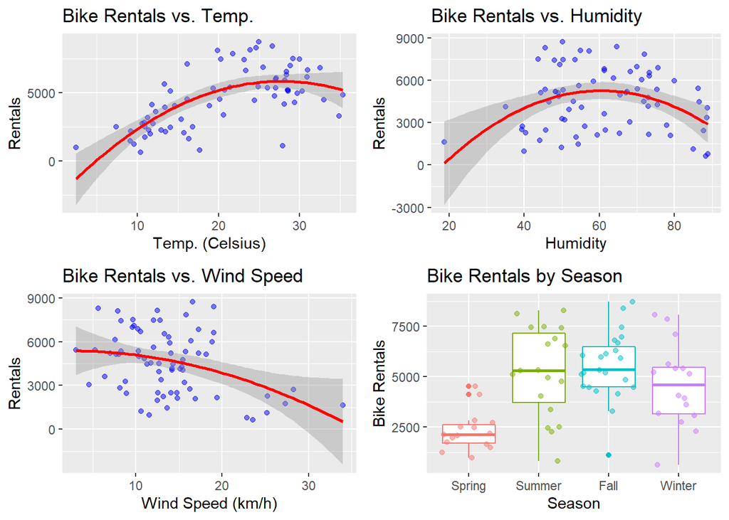

Finally, let’s examine the distributions of bike rentals by weather situation and year.

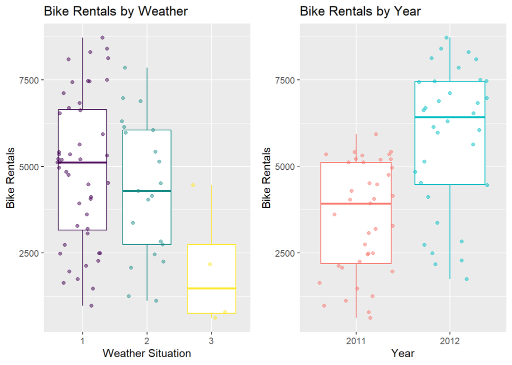

Now we are ready to move onto modeling.

# Modeling

We want to predict bike rental demand in a given day conditional on weather-related variables, the season, and the year. These can be known *a prior*. We will try linear and ensemble modeling approaches.

```r
# Set the parameters for repeated k-folds CV.
k <- 5
repeats <- 3

# Create a trainControl object for repeated k-folds CV.
trCntrl <- trainControl(method="repeatedcv", number=k, repeats=repeats)
```

We are doing 5-folds CV with 3 repeats.

## Linear models

### Linear Model 1

For our first model, we are assuming the number of bike rentals has quadratic relationships with temperature, wind speed, and humidity, with seasonal effects, and a linear trend for year. The linear trend of year will probably perform particularly poorly for extrapolation. As the bike rental company is around longer, their rate of yearly growth will decrease as they approach market saturation. The model is shown below.

$$\text{# of rentals}_i = \beta_0 + \beta_1\text{temp}_i + \beta_2\text{temp}_i^2 + \beta_3\text{wind speed}_i + \beta_4\text{wind speed}_i^2 + \beta_5\text{humidity}_i + \beta_6\text{humidity}_i^2 + \beta_7\text{Summer}_i +\beta_8\text{Fall}_i + \beta_9\text{Winter}_i + \beta_{10}\text{year}_i + \epsilon_i$$
Where $\epsilon_i \overset{\text{iid}}\sim \text{N}(0, \sigma^2)$.

Now let’s evaluate the performance of linear model 1.

```r
# Evaluate a linear model of the specified form in repeated k-folds CV and fit
# it to the training set.
linMod1 <- train(
  cnt ~ temp + I(temp^2) + windspeed + I(windspeed^2) + hum + I(hum^2)
  + season + yr,
  data=bikeTrain,
  method="lm",
  trControl=trCntrl
  )
linMod1
```

```
## Linear Regression
##
## 73 samples
##  5 predictor
##
## No pre-processing
## Resampling: Cross-Validated (5 fold, repeated 3 times)
## Summary of sample sizes: 58, 57, 59, 59, 59, 58, ...
## Resampling results:
##
##   RMSE      Rsquared   MAE
##   1015.012  0.8234593  721.0828
##
## Tuning parameter 'intercept' was held constant at a value of TRUE
```

### Linear Model 2

In our second model, we assume the same combination of variables and any quadratic effects are modeling a poisson process. This assumption is based on bike rentals being a count and our count occurs in a set amount of time (a single day).

```r
# Evaluate a linear model of the specified form in repeated k-folds CV and fit
# it to the training set.
linMod2 <- train(
  cnt ~ temp + I(temp^2) + windspeed + I(windspeed^2) + hum + I(hum^2)
  + season + yr,
  data=bikeTrain,
  method="glm",
  family="poisson",
  trControl=trCntrl
  )

linMod2
```

```
## Generalized Linear Model
##
## 73 samples
##  5 predictor
##
## No pre-processing
## Resampling: Cross-Validated (5 fold, repeated 3 times)
## Summary of sample sizes: 58, 59, 59, 58, 58, 60, ...
## Resampling results:
##
##   RMSE      Rsquared  MAE
##   795.6432  0.878179  640.9725
```

## Ensemble Tree Models

We try random forests and gradient boosted trees, tuning the hyper-parameter grid.

### Random Forest

We try a random forest here.

```r
# Perform the grid search through repeated CV.
rfFit <- train (
  cnt ~ temp + windspeed + hum + season + yr,
  data=select(bikeTrain, -"weekday"),
  method="rf",
  preProcess= c("center", "scale"),
  trControl = trCntrl,
  tuneGrid=expand.grid(mtry=c(100, 500, 1000))
  )

rfFit$results %>%
  filter(RMSE == min(RMSE))
```

```
##   mtry     RMSE  Rsquared      MAE   RMSESD RsquaredSD    MAESD
## 1  100 1041.158 0.7801215 782.1966 237.6968 0.09569888 176.0225
```

### Boosted Trees

Boosting is a way to slowly train a tree. Each tree is created based on previous one. As a result, the variance is aimed to decrease.

```r
# Set grid of tuning parameters to try.
gbmGrid <- expand.grid(
  interaction.depth=c(1, 4, 6),
  n.trees=c(100, 500),
  shrinkage=c(0.01, 0.1),
  n.minobsinnode=c(3, 10)
)

# Perform the grid search through repeated CV.
gbmFit <- train (
  cnt ~ temp + windspeed + hum + season + yr,
  data=select(bikeTrain, -"weekday"),
  method="gbm",
  preProcess= c("center", "scale"),
  trControl = trCntrl,
  tuneGrid=gbmGrid
  )
```

```r
gbmFit$results %>%
  filter(RMSE == min(RMSE))
```

```
##   shrinkage interaction.depth n.minobsinnode n.trees     RMSE Rsquared      MAE
## 1       0.1                 4              3     100 868.7374 0.847863 682.0983
##     RMSESD RsquaredSD    MAESD
## 1 142.5087 0.05230295 115.6691
```

### Comparing the Models

Let’s evaluate their repeated k-folds CV performance first.

Table 3: Repeated k-folds CV Performance Summary

[output not shown]

Now let’s look at their test set performance.

Table 4: Test Set Performance Summary

|  | RMSE | Rsquared | MAE |
| --- | --- | --- | --- |
| OLS | 999.67 | 0.81 | 820.36 |
| Poisson Regression | 949.79 | 0.83 | 706.02 |
| Random Forest | 984.87 | 0.84 | 785.16 |
| Boosted Trees | 664.29 | 0.93 | 483.12 |

The best performing model is the Boosted Trees with an RMSE of 664.29.